# Week 4 Developing Data Products

author: Zito Relova date: January 28, 2019 autosize: true

# Overview

This application allows the user to predict their average miles per gallon (MPG) consumption based on different attributes of their car. The user interface uses a mix of sliders and radio buttons in order to select the attributes.

# Car Attributes

- cyl - the number of cylinders in the engine
- disp - the engine displacement in cubic inches
- hp - the engine’s gross horsepower in HP
- drat - the rear axle ratio
- wt - the weight in 1000’s of lbs
- qsec - the 1/4 mile time in seconds
- vs - the engine cylinder configuration(V-shape or straight)
- am - the transmission type (automatic or manual)
- gear - the number of forward gears in the transmission
- carb - the number of carburetor barrels
- mpg - miles per gallon calculation

```
 [1] "mpg"  "cyl"  "disp" "hp"   "drat" "wt"   "qsec" "vs"   "am"   "gear"
[11] "carb"
```

# Model

In order to accurately predict the average MPG consumption of the vehicle, a random forest model was used. The input to the model were the car attributes eg. cyl, disp, hp, etc. and the output was the number of miles per gallon.

# User Interface

Here is the application’s interface.

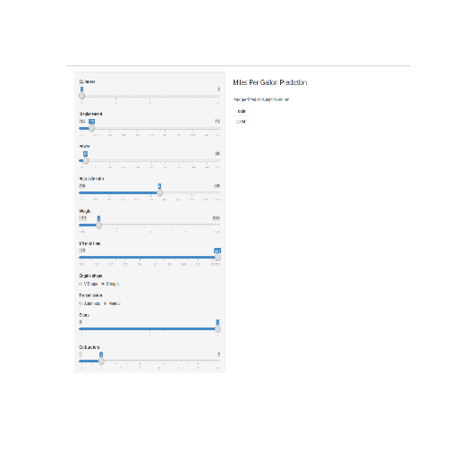